# **MATH 3190 Homework 9**

Due April 9, 2026  
Focus: Notes 10  
Total Points: 70 + 10 (Self-Critique Comment and Uploading to GitHub) = 80

Note that your homework should be completed in Quarto. You can just add your answers and code to this document in the appropriate part. The file should be rendered as an html document or pdf document (html is quicker to render and you will need an installation of LaTeX to render as a pdf). You will “turn in” this homework by uploading the files, the .qmd and output file, to your GitHub `Math_3190_Assignment` repository in the `Homework/Homework_9` directory. Make sure all supporting files (if there are any) are in this directory as well. You should use `git` and `Unix` commands in a terminal for this (i.e. don’t manually upload files to GitHub). In addition, you will submit just your html or pdf file on Canvas to unlock the solutions.

Don’t forget to also put a self-critique comment on Canvas indicating what you did correctly and incorrectly and include any questions you may have about the assignment after submitting the assignment and thoroughly looking through the solutions.

# Problem 1 (70 points)

Before we begin, please re-install the `math3190package` since there was an update to the `classifier_plot()` function that is needed on this assignment. Use either `devtools::install_github("rbrown53/math3190package")` or  
`remotes::install_github("rbrown53/math3190package")`.

The National Institute of Diabetes and Digestive and Kidney Diseases conducted a study on 768 adult female Pima Native Americans living near Phoenix. The purpose of the study was to investigate factors related to diabetes. The response variable in this study (test) was whether or not the patient showed signs of diabetes (1 = yes, 0 = no). One explanatory variable considered was the plasma glucose concentration (in mg/dL) at 2 hours in an oral glucose tolerance test (glucose). Many other potential explanatory variables were considered as well including body mass index (BMI). The goal here is to predict the diabetes status of the subject, which is in the `results` variable.

### Part a (5 points)

Install and/or load the `faraway` package with the `pima` dataset. Set a seed and then split the data into a testing and a training set with the testing set containing 20% of the data values. When you do this, change the name of the variable “test” to “result” since it will be a bit confusing to call that test when we have a test dataset. Then make the `result` variable a factor so **R** treats it as categorical rather than numeric.

```r
library(faraway)
set.seed(3190)

# column rename
names(pima)[names(pima) == "test"] <- "result"
pima$result <- as.factor(pima$result)

# split
n <- nrow(pima)
train_indices <- sample(1:n, size = floor(0.80 * n))
train_set <- pima[train_indices, ]
test_set <- pima[-train_indices, ]
```

### Part b (6 points)

- Fit a logistic regression model to the training set for predicting `result` from the `glucose` and `bmi` variables.
- Then use the `classifier_plot()` function in the `math3190package` (make sure you re-installed it!) to make a plot that shows the regions on the `glucose`-`bmi`-plane that are predicted to be 0 and 1. This shows how logistic regression divides the classes. Use the **training set** as the `data` input in this function.
- Next, obtain the predictions for the **test set** with a probability cutoff of 0.5 to predict if the person has diabetes. Create a confusion matrix using the `confusionMatrix()` function in the `caret` library. Make sure to put `positive = "1"` for this and all other confusion matrices on this assignment. Print all of the output from that function that shows the confusion matrix and many associated statistics.
- Write a sentence or two discussing how well this model performs in predicting on the test set.

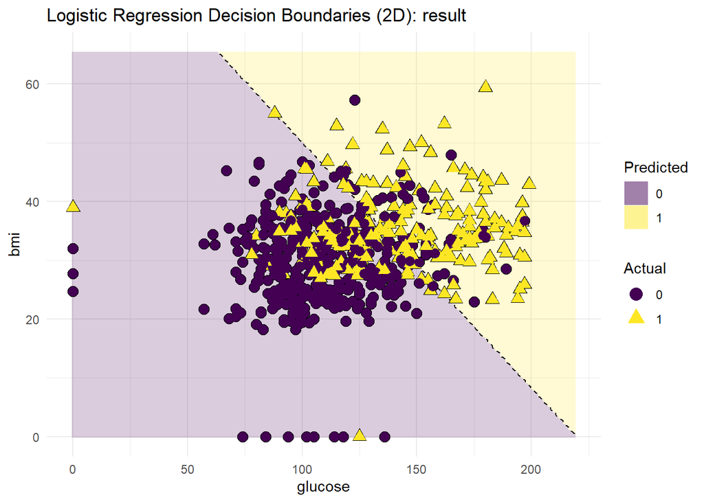

```r
library(math3190package)
library(caret)

# fit logistic model
pima_logit <- glm(result ~ glucose + bmi, data = train_set, family = binomial)

# Visualize
classifier_plot(pima_logit, train_set)
```

```r
# Test set confusion matrix
test_probs <- predict(pima_logit, newdata = test_set, type = "response")
test_preds <- factor(ifelse(test_probs > 0.5, "1", "0"), levels = c("0", "1"))
conf_matrix <- confusionMatrix(test_preds, test_set$result, positive = "1")
print(conf_matrix)
```

```
Confusion Matrix and Statistics

          Reference
Prediction  0  1
         0 81 28
         1 14 31

               Accuracy : 0.7273
                 95% CI : (0.6497, 0.7958)
    No Information Rate : 0.6169
    P-Value [Acc > NIR] : 0.002635

                  Kappa : 0.3959

 Mcnemar's Test P-Value : 0.044862

            Sensitivity : 0.5254
            Specificity : 0.8526
         Pos Pred Value : 0.6889
         Neg Pred Value : 0.7431
             Prevalence : 0.3831
         Detection Rate : 0.2013
   Detection Prevalence : 0.2922
      Balanced Accuracy : 0.6890

       'Positive' Class : 1
```

- The model evidently works. The p-value is significant, but the type II error rate is high with a sensitivity of only 0.5254. We could do much better

### Part c (3 points)

Now let’s use naïve Bayes to get predictions. Use the `naive_bayes()` function in the `naivebayes` library to fit a model predicting result using `glucose` and `bmi`. Find the predicted probabilities of being a 0 and a 1 for the first observation in the training set.

```r
# Naive Bayes
library(naivebayes)
pima_nb <- naive_bayes(result ~ glucose + bmi, data = train_set, usekernel= FALSE )
first_obs <- train_set[1, ]
first_prob <- predict(pima_nb, newdata = first_obs, type = "prob")
print(first_prob)
```

```
             0         1
[1,] 0.8867336 0.1132664
```

### Part d (9 points)

Now find the predicted probability of being a 0 and a 1 for the first observation in the training set “by hand” like we did in the notes on pages 187 and 188. To simplify this a bit, let’s again only use the variables `glucose` and `bmi` here. Of course, use **R** to help you (the `dnorm()` function and some tidyverse functions will be especially nice), but don’t use the `naive_bayes()` function here. Note: these variables we are using to predict are numeric, so we will assume a normal distribution for both of them (maybe not a good assumption, but let’s go with it). After you get the probabilities, compare them to the ones you got in part (c). They should match.

```r
library(tidyverse)

# Get the feature values for the first observation
obs1 <- train_set[1, ]
x_gluc <- obs1$glucose
x_bmi <- obs1$bmi

# priors
priors <- train_set |>
  count(result)|>
  mutate(prob = n / sum(n))

p_0 <- priors$prob[priors$result == 0]
p_1 <- priors$prob[priors$result == 1]

# mean and sd
stats <- train_set %>%
  group_by(result) %>%
  summarise(
    mean_gluc = mean(glucose),
    sd_gluc = sd(glucose),
    mean_bmi = mean(bmi),
    sd_bmi = sd(bmi)
  )

# P(0)
lik_0 <- dnorm(x_gluc, mean = stats$mean_gluc[1], sd = stats$sd_gluc[1]) *
  dnorm(x_bmi, mean = stats$mean_bmi[1], sd = stats$sd_bmi[1])

# P(1)
lik_1 <- dnorm(x_gluc, mean = stats$mean_gluc[2], sd = stats$sd_gluc[2]) *
  dnorm(x_bmi, mean = stats$mean_bmi[2], sd = stats$sd_bmi[2])

# Prior * Likelihood
post_0_unnorm <- p_0 * lik_0
post_1_unnorm <- p_1 * lik_1

# Normalize so they sum to 1
prob_0 <- post_0_unnorm / (post_0_unnorm + post_1_unnorm)
prob_1 <- post_1_unnorm / (post_0_unnorm + post_1_unnorm)

# Results
cat(
  "Manual Probabilities for Obs 1:\n",
  "Result 0:",
  prob_0,
  "\n Result 1:",
  prob_1
)
```

```
Manual Probabilities for Obs 1:
 Result 0: 0.8867336
 Result 1: 0.1132664
```

### Part e (3 points)

Now fit a naïve Bayes model predicting `result` from `glucose` and `bmi` using a kernel instead of assuming a normal distribution. You can do this by setting `usekernel = TRUE` in the `naive_bayes()` function.

```r
kernel_nb <- naive_bayes(result ~ glucose + bmi, data=train_set, usekernal=TRUE)
head(predict(kernel_nb, type='prob')) |> round(3)
```

```
         0     1
[1,] 0.887 0.113
[2,] 0.999 0.001
[3,] 0.898 0.102
[4,] 0.466 0.534
[5,] 0.604 0.396
[6,] 0.909 0.091
```

### Part f (5 points)

Now use the `classifier_plot()` function to make two plots: one using the first naïve Bayes from part (c) and one using the naïve Bayes with the kernel from part (e). Both should show the separation on the **training set**. Comment on how these models seems to perform in separating the results classes and if there seems like there may be any over-fitting here.

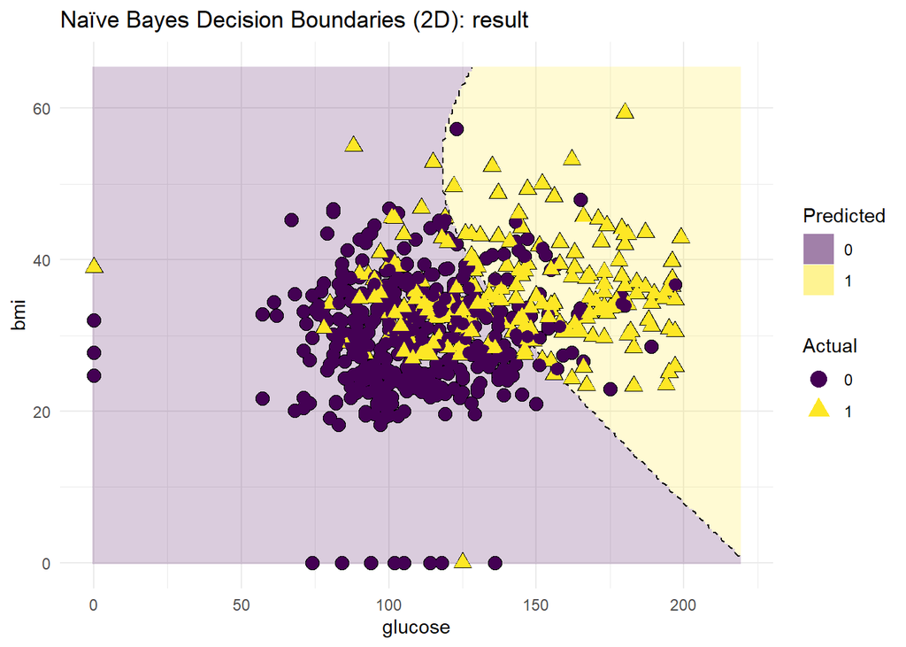

```r
classifier_plot(pima_nb, train_set)
```

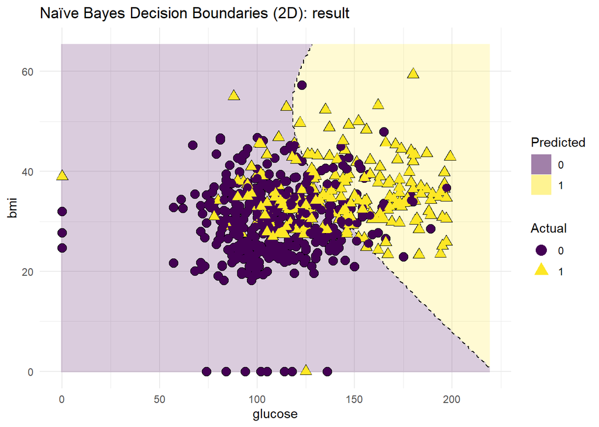

```r
classifier_plot(kernel_nb, train_set)
```

### Part g (5 points)

Report the output of the `confusionMatrix()` function for both naïve Bayes models when predicting on the **test** set. Write a couple sentences comparing the confusion matrix statistics.

```r
# Predictions
preds_nb <- predict(pima_nb, newdata = test_set)
cm_nb <- confusionMatrix(preds_nb, test_set$result, positive = "1")
preds_kernel <- predict(kernel_nb, newdata = test_set)
cm_kernel <- confusionMatrix(preds_kernel, test_set$result, positive = "1")

# More idiomatic R printing for Quarto
cat("--- Naive Bayes Results ---\n")
```

```
--- Naive Bayes Results ---
```

```r
print(cm_nb)
```

```
Confusion Matrix and Statistics

          Reference
Prediction  0  1
         0 81 29
         1 14 30

               Accuracy : 0.7208
                 95% CI : (0.6429, 0.79)
    No Information Rate : 0.6169
    P-Value [Acc > NIR] : 0.004448

                  Kappa : 0.3794

 Mcnemar's Test P-Value : 0.032763

            Sensitivity : 0.5085
            Specificity : 0.8526
         Pos Pred Value : 0.6818
         Neg Pred Value : 0.7364
             Prevalence : 0.3831
         Detection Rate : 0.1948
   Detection Prevalence : 0.2857
      Balanced Accuracy : 0.6806

       'Positive' Class : 1
```

```r
cat("\n--- Kernel Naive Bayes Results ---\n")
```

```
--- Kernel Naive Bayes Results ---
```

```r
print(cm_kernel)
```

```
Confusion Matrix and Statistics

          Reference
Prediction  0  1
         0 81 29
         1 14 30

               Accuracy : 0.7208
                 95% CI : (0.6429, 0.79)
    No Information Rate : 0.6169
    P-Value [Acc > NIR] : 0.004448

                  Kappa : 0.3794

 Mcnemar's Test P-Value : 0.032763

            Sensitivity : 0.5085
            Specificity : 0.8526
         Pos Pred Value : 0.6818
         Neg Pred Value : 0.7364
             Prevalence : 0.3831
         Detection Rate : 0.1948
   Detection Prevalence : 0.2857
      Balanced Accuracy : 0.6806

       'Positive' Class : 1
```

### Part h (3 points)

Now let’s use a support vector machine (SVM) for classifying diabetes using all other variables. We’ll use the `svm()` function in the `e1071` library. Fit a model with a **polynomial** kernel here with degree 3 (the default), a cost of 1 (also the default), and keep `scale = TRUE` (which is the default as well). Ideally, we would do a cross validation to select the cost, but we’ll do that for the next kernel.

```r
library(e1071)

# SVM model
pima_svm_poly <- svm(
  result ~ glucose + bmi,
  data = train_set,
  kernel = "polynomial",
  degree = 3,
  cost = 1,
  scale = TRUE
)

svm_poly_preds <- predict(pima_svm_poly, newdata = test_set)

# Create the confusion matrix
conf_matrix_svm <- confusionMatrix(
  svm_poly_preds,
  test_set$result,
  positive = "1"
)

print(conf_matrix_svm)
```

```
Confusion Matrix and Statistics

          Reference
Prediction  0  1
         0 88 40
         1  7 19

               Accuracy : 0.6948
                 95% CI : (0.6156, 0.7664)
    No Information Rate : 0.6169
    P-Value [Acc > NIR] : 0.027

                  Kappa : 0.2778

 Mcnemar's Test P-Value : 3.046e-06

            Sensitivity : 0.3220
            Specificity : 0.9263
         Pos Pred Value : 0.7308
         Neg Pred Value : 0.6875
             Prevalence : 0.3831
         Detection Rate : 0.1234
   Detection Prevalence : 0.1688
      Balanced Accuracy : 0.6242

       'Positive' Class : 1
```

### Part i (10 points)

Now let’s use a different kernel. Let’s use the radial kernel for the SVM. This has two tuning parameters: the cost and $\gamma$. Let’s use the `train()` function in the `caret` package to do 5-fold cross validation (set a seed, please) to select both of those parameters. However, the `train()` function uses $\sigma$ instead of $\gamma$ and $C$ instead of cost.

Use the `trainControl()` function with the `trControl` option and the `tuneGrid` option in the `train()` function to perform this cross-validation. For `sigma`, use `seq(0.1, 2, by = 0.1)` and for `C` also use `seq(0.1, 2, by = 0.1)`. Put `method = "svmRadial"` in the `train()` function as well so it knows to use a SVM with the radial kernel. You will need to install the `kernlab` package for this to work. Set a seed here as well.

By default, the “best” sigma and C values will be chosen with accuracy instead of Cohen’s kappa. Make sure to choose the best values using kappa (although both metrics may choose the same “best” values).

```r
library(caret)
library(kernlab)

# Set seed
set.seed(3190)

# Cross-validation control (5-fold)
cv_ctrl <- trainControl(method = "cv", number = 5)

# Tuning Grid
svm_grid <- expand.grid(
  sigma = seq(0.1, 2, by = 0.1),
  C = seq(0.1, 2, by = 0.1)
)

svm_radial_tuned <- train(
  result ~ glucose + bmi,
  data = train_set,
  method = "svmRadial",
  trControl = cv_ctrl,
  tuneGrid = svm_grid,
  metric = "Kappa"
)

# Output
print(svm_radial_tuned$bestTune)
```

```
    sigma   C
313   1.6 1.3
```

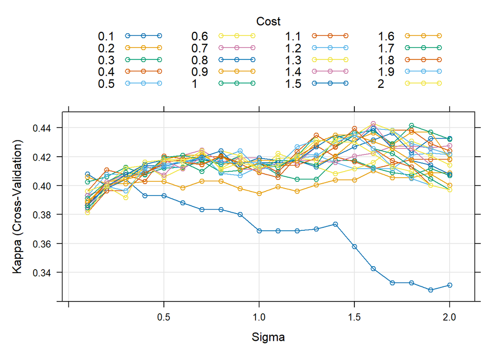

```r
plot(svm_radial_tuned)
```

### Part j (3 points)

Fit the SVM with the **radial** kernel using the `svm()` function and the cross-validated cost and $\gamma$ found in part (i).

```r
# Best Sigma
best_sigma <- svm_radial_tuned$bestTune$sigma
best_cost <- svm_radial_tuned$bestTune$C

# Final svm
pima_svm_final <- svm(
  result ~ glucose + bmi,
  data = train_set,
  kernel = "radial",
  gamma = best_sigma,
  cost = best_cost,
  scale = TRUE
)

summary(pima_svm_final)
```

```
Call:
svm(formula = result ~ glucose + bmi, data = train_set, kernel = "radial",
    gamma = best_sigma, cost = best_cost, scale = TRUE)


Parameters:
   SVM-Type:  C-classification
 SVM-Kernel:  radial
       cost:  1.3

Number of Support Vectors:  337

 ( 176 161 )


Number of Classes:  2

Levels:
 0 1
```

### Part k (5 points)

Create the classifier plots for both SVM models and plot the training set and comment on how well these seem to separate the classes.

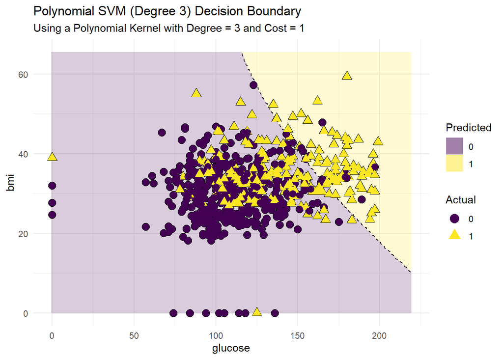

```r
# Plot for the Polynomial SVM
classifier_plot(pima_svm_poly, train_set) +
  ggtitle("Polynomial SVM (Degree 3) Decision Boundary")
```

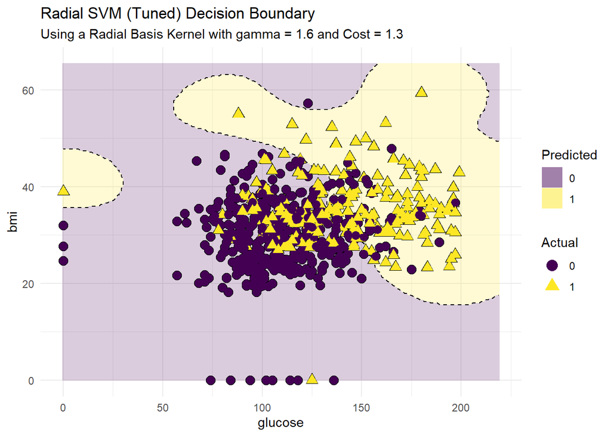

```r
# Plot for the Tuned Radial SVM
classifier_plot(pima_svm_final, train_set) +
  ggtitle("Radial SVM (Tuned) Decision Boundary")
```

### Part l (3 points)

Report the confusion matrix statistics for both SVM models when predicting the **test** set.

```r
# Polynomial SVM
poly_test_preds <- predict(pima_svm_poly, newdata = test_set)
cm_poly <- confusionMatrix(poly_test_preds, test_set$result, positive = "1")

# Tuned Radial SVM
final_test_preds <- predict(pima_svm_final, newdata = test_set)
cm_radial <- confusionMatrix(final_test_preds, test_set$result, positive = "1")

# Print the full stats for both
cat("--- Polynomial SVM Test Results ---\n")
```

```
--- Polynomial SVM Test Results ---
```

```r
print(cm_poly)
```

```
Confusion Matrix and Statistics

          Reference
Prediction  0  1
         0 88 40
         1  7 19

               Accuracy : 0.6948
                 95% CI : (0.6156, 0.7664)
    No Information Rate : 0.6169
    P-Value [Acc > NIR] : 0.027

                  Kappa : 0.2778

 Mcnemar's Test P-Value : 3.046e-06

            Sensitivity : 0.3220
            Specificity : 0.9263
         Pos Pred Value : 0.7308
         Neg Pred Value : 0.6875
             Prevalence : 0.3831
         Detection Rate : 0.1234
   Detection Prevalence : 0.1688
      Balanced Accuracy : 0.6242

       'Positive' Class : 1
```

```r
cat("\n--- Tuned Radial SVM Test Results ---\n")
```

```
--- Tuned Radial SVM Test Results ---
```

```r
print(cm_radial)
```

```
Confusion Matrix and Statistics

          Reference
Prediction  0  1
         0 80 28
         1 15 31

               Accuracy : 0.7208
                 95% CI : (0.6429, 0.79)
    No Information Rate : 0.6169
    P-Value [Acc > NIR] : 0.004448

                  Kappa : 0.3835

 Mcnemar's Test P-Value : 0.067253

            Sensitivity : 0.5254
            Specificity : 0.8421
         Pos Pred Value : 0.6739
         Neg Pred Value : 0.7407
             Prevalence : 0.3831
         Detection Rate : 0.2013
   Detection Prevalence : 0.2987
      Balanced Accuracy : 0.6838

       'Positive' Class : 1
```

### Part m (10 points)

Compare the output of the `confusionMarix()` function for all of our classifiers: the logistic regression model, the naïve Bayes with a normal assumption, the naïve Bayes using kernel density estimation, the SVM with a polynomial kernel, and the SVM using a radial kernel. Which was best? Which was worst? How different were the results? You can focus on the Cohen’s $\kappa$ and balanced accuracy for each one.

```r
comparison_df <- tibble(
  Model = c(
    "Logistic Regression",
    "Naive Bayes (Both)",
    "SVM (Radial Tuned)",
    "SVM (Polynomial)"
  ),
  Accuracy = c(0.7273, 0.7208, 0.7208, 0.6948),
  Balanced_Accuracy = c(0.6890, 0.6806, 0.6838, 0.6242),
  Kappa = c(0.3959, 0.3794, 0.3835, 0.2778),
  Sensitivity = c(0.5254, 0.5085, 0.5254, 0.3220)
) |> print()
```

```
# A tibble: 4 × 5
  Model               Accuracy Balanced_Accuracy Kappa Sensitivity
  <chr>                  <dbl>             <dbl> <dbl>       <dbl>
1 Logistic Regression    0.727             0.689 0.396       0.525
2 Naive Bayes (Both)     0.721             0.681 0.379       0.508
3 SVM (Radial Tuned)     0.721             0.684 0.384       0.525
4 SVM (Polynomial)       0.695             0.624 0.278       0.322
```